# Predicting Exercise Quality from Wearable Accelerometers

Ulzhan Askarkyzy

2026-11-09

## Data and preprocessing

The training dataset and 20-case testing dataset are provided by the Practical Machine Learning course. Removing administrative identifiers, timestamps, and columns with extensive missingness reduces leakage and produces comparable measurement features across training and testing.

```r
train_url <- 'https://d396qusza40orc.cloudfront.net/predmachlearn/pml-training.csv'
test_url  <- 'https://d396qusza40orc.cloudfront.net/predmachlearn/pml-testing.csv'
if (!file.exists('pml-training.csv')) download.file(train_url, 'pml-training.csv', mode='wb')
if (!file.exists('pml-testing.csv')) download.file(test_url, 'pml-testing.csv', mode='wb')
raw_train <- read.csv('pml-training.csv', na.strings=c('', 'NA', '#DIV/0!'))
raw_test  <- read.csv('pml-testing.csv', na.strings=c('', 'NA', '#DIV/0!'))
stopifnot(nrow(raw_test) == 20, 'classe' %in% names(raw_train))
exclude <- c('X','user_name','raw_timestamp_part_1','raw_timestamp_part_2',
             'cvtd_timestamp','new_window','num_window','classe','problem_id')
candidate <- intersect(setdiff(names(raw_train), exclude), names(raw_test))
keep <- candidate[vapply(candidate, function(z) {
  is.numeric(raw_train[[z]]) && is.numeric(raw_test[[z]]) &&
  mean(is.na(raw_train[[z]])) < 0.05 && all(!is.na(raw_test[[z]]))
}, logical(1))]
dat <- raw_train[, c(keep, 'classe')]
dat <- dat[complete.cases(dat), ]
dat$classe <- factor(dat$classe)
quiz <- raw_test[, keep, drop=FALSE]
cat('Training rows:', nrow(dat), '; predictor columns:', length(keep), '\n')
```

```
## Training rows: 19622 ; predictor columns: 52
```

```r
print(table(dat$classe))
```

```
##
##    A    B    C    D    E
## 5580 3797 3422 3216 3607
```

## Exploratory analysis

The bar plot below summarizes class balance. Class proportions should be preserved in splitting and cross-validation.

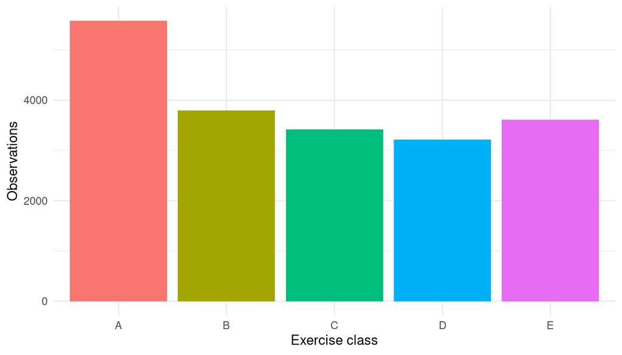

Counts of exercise quality classes in training data

```r
ggplot(dat, aes(x=classe, fill=classe)) + geom_bar(show.legend=FALSE) +
  labs(x='Exercise class', y='Observations') + theme_minimal()
```

## Model selection and cross-validation

```r
idx <- createDataPartition(dat$classe, p=0.70, list=FALSE)
dev <- dat[idx, , drop=FALSE]
holdout <- dat[-idx, , drop=FALSE]
ctrl <- trainControl(method='cv', number=3)
fit_tree <- train(classe ~ ., data=dev, method='rpart', trControl=ctrl,
                  tuneLength=5, metric='Accuracy')
fit_rf <- train(classe ~ ., data=dev, method='rf', trControl=ctrl,
                tuneLength=1, metric='Accuracy', ntree=50)
comparison <- resamples(list(Tree=fit_tree, RandomForest=fit_rf))
print(summary(comparison))
```

```
##
## Call:
## summary.resamples(object = comparison)
##
## Models: Tree, RandomForest
## Number of resamples: 3
##
## Accuracy
##                   Min.   1st Qu.    Median      Mean   3rd Qu.      Max. NA's
## Tree         0.5277414 0.5690683 0.6103953 0.5961183 0.6303068 0.6502183    0
## RandomForest 0.9890806 0.9890818 0.9890830 0.9892990 0.9894082 0.9897335    0
##
## Kappa
##                   Min.   1st Qu.    Median      Mean   3rd Qu.      Max. NA's
## Tree         0.3847832 0.4449816 0.5051801 0.4830862 0.5322376 0.5592952    0
## RandomForest 0.9861865 0.9861885 0.9861905 0.9864629 0.9866011 0.9870116    0
```

```r
selected <- if (max(fit_rf$results$Accuracy) >= max(fit_tree$results$Accuracy)) fit_rf else fit_tree
cat('Selected model:', selected$method, '\n')
```

```
## Selected model: rf
```

## Out-of-sample performance

The holdout set was never used for model selection. Its misclassification rate is our estimate of expected error for additional observations drawn comparably to the training data. Results may differ somewhat with a different random seed, split, or R/package version. Performance can be lower for new people, devices, or collection conditions.

```r
hold_pred <- predict(selected, newdata=holdout)
cm <- confusionMatrix(hold_pred, holdout$classe)
print(cm)
```

```
## Confusion Matrix and Statistics
##
##           Reference
## Prediction    A    B    C    D    E
##          A 1673   11    0    0    0
##          B    1 1124    4    0    0
##          C    0    4 1019    7    0
##          D    0    0    3  956    3
##          E    0    0    0    1 1079
##
## Overall Statistics
##
##                Accuracy : 0.9942
##                  95% CI : (0.9919, 0.996)
##     No Information Rate : 0.2845
##     P-Value [Acc > NIR] : < 2.2e-16
##
##                   Kappa : 0.9927
##
##  Mcnemar's Test P-Value : NA
##
## Statistics by Class:
##
##                      Class: A Class: B Class: C Class: D Class: E
## Sensitivity            0.9994   0.9868   0.9932   0.9917   0.9972
## Specificity            0.9974   0.9989   0.9977   0.9988   0.9998
## Pos Pred Value         0.9935   0.9956   0.9893   0.9938   0.9991
## Neg Pred Value         0.9998   0.9968   0.9986   0.9984   0.9994
## Prevalence             0.2845   0.1935   0.1743   0.1638   0.1839
## Detection Rate         0.2843   0.1910   0.1732   0.1624   0.1833
## Detection Prevalence   0.2862   0.1918   0.1750   0.1635   0.1835
## Balanced Accuracy      0.9984   0.9929   0.9955   0.9952   0.9985
```

```r
acc <- as.numeric(cm$overall['Accuracy'])
n <- nrow(holdout)
errors <- sum(hold_pred != holdout$classe)
cat(sprintf('Holdout accuracy: %.4f; estimated out-of-sample error: %.4f (%d/%d)\n',
            acc, errors/n, errors, n))
```

```
## Holdout accuracy: 0.9942; estimated out-of-sample error: 0.0058 (34/5885)
```

```r
cat('Approximate 95% binomial interval for error rate:\n')
```

```
## Approximate 95% binomial interval for error rate:
```

```r
print(binom.test(errors, n)$conf.int)
```

```
## [1] 0.004004238 0.008064064
## attr(,"conf.level")
## [1] 0.95
```

## Predictions for the 20 course cases

For the quiz predictions, the model selected above is refit on the entire labeled dataset using the selected algorithm and tuning parameter. This maximizes the training information available at final prediction time.

```r
final_model <- if (selected$method == 'rf') {
  randomForest(classe ~ ., data=dat, mtry=selected$bestTune$mtry, ntree=500)
} else {
  rpart(classe ~ ., data=dat, cp=selected$bestTune$cp)
}
quiz_pred <- predict(final_model, newdata=quiz)
print(data.frame(problem_id=raw_test$problem_id, prediction=quiz_pred), row.names=FALSE)
```

```
##  problem_id prediction
##           1          B
##           2          A
##           3          B
##           4          A
##           5          A
##           6          E
##           7          D
##           8          B
##           9          A
##          10          A
##          11          B
##          12          C
##          13          B
##          14          A
##          15          E
##          16          E
##          17          A
##          18          B
##          19          B
##          20          B
```

```r
write.csv(data.frame(problem_id=raw_test$problem_id, prediction=quiz_pred),
          'quiz_predictions.csv', row.names=FALSE)
```

## Discussion and limitations

This approach uses a physically meaningful set of sensor measurements and excludes variables likely to leak recording order, participant identities, or time. Cross-validation helps choose between a simple interpretable tree and a flexible ensemble, while a separate holdout guards against overly optimistic training performance. The reported validation accuracy is conditional on a random row-wise split: sessions from the same six participants may occur in both subsets. Therefore, the error rate may understate error for entirely new participants. A group-based validation design would better estimate transfer to unseen individuals.

## Data attribution

Weight Lifting Exercises Dataset, provided by the original researchers through the Coursera Practical Machine Learning course. Original project: https://web.archive.org/web/20161224072740/http:/groupware.les.inf.puc-rio.br/har